# A Quick Introduction to iNEXT.seq via Example

### MAIN FUNCTION: ObsAsyPD()

We first describe the main function `ObsAsyPD()` with default arguments:

```r
ObsAsyPD(data, q = seq(0, 2, 0.2), weight = "size", nboot = 10, conf = 0.95,
         PDtree, type = "mle", decomposition = "relative")
```

The arguments of this function are briefly described below, and will be explained in more details by illustrative examples in later text. This main function computes observed and asymptotic diversity of order q between 0 and 2 (in increments of 0.2) for multiple-assemblage phylogenetic diversity; these values with different order q can be used to depict a q-profile in the `ggObsAsyPD` function.

| Argument | Description |
| --- | --- |
| `data` | OTU count data can be input as a `matrix/data.frame` (species by assemblages), or a list of `matrices/data.frames`, each matrix represents species-by-assemblages abundance matrix. |
| `q` | a numerical vector specifying the diversity orders. Default is `seq(0, 2, 0.2)`. |
| `weight` | (required only when `type = “mle”` and decomposition = “relative” ) weight for relative decomposition empirical estimate. Select size-weighted (`“size”`), equal-weighted (`“equal”`) or a numerical vec… |
| `nboot` | a positive integer specifying the number of bootstrap replications when assessing sampling uncertainty and constructing confidence intervals. Bootstrap replications are generally time consuming. Enter… |
| `conf` | a positive number < 1 specifying the level of confidence interval. Default is `0.95`. |
| `PDtree` | a `phylo`, a phylogenetic tree in Newick format for all observed species in the pooled assemblage. |
| `type` | estimate type: empirical (`type = “mle”`) or asymptotic estimate (`type = “est”`). Default is `“mle”`. |
| `decomposition` | decomposition type: relative (`decomposition = “relative”`) or absolute decomposition (`decomposition = “absolute”`). Default is `“relative”`. |

This function returns an `"ObsAsyPD"` object which can be further used to make plots using the function `ggObsAsyPD()` to be described below.

#### Examples

Run the `ObsAsyPD()` function with `esophagus` data to compute empirical estimate for relative decomposition of multiple-assemblage phylogenetic diversity. (Here we only show the first fourteen rows for output data frame)

```r
data("esophagus")
data("esophagus_tree")

ObsAsyPD_out = ObsAsyPD(data = esophagus[1], q = seq(0, 2, 0.2), nboot = 10,
                        PDtree = esophagus_tree)
```

```
#> $esophagus_BC
#>         Dataset Method Order.q Estimator Bootstrap S.E.    LCL    UCL Decomposition
#> 1  esophagus_BC  Gamma     0.0    14.550          0.827 12.929 16.172      relative
#> 2  esophagus_BC  Alpha     0.0    11.174          0.488 10.218 12.130      relative
#> 3  esophagus_BC   Beta     0.0     1.302          0.048  1.207  1.397      relative
#> 4  esophagus_BC 1-CqN*     0.0     0.311          0.047  0.219  0.403      relative
#> 5  esophagus_BC 1-UqN*     0.0     0.471          0.049  0.374  0.568      relative
#> 6  esophagus_BC 1-VqN*     0.0     0.311          0.047  0.219  0.403      relative
#> 7  esophagus_BC 1-SqN*     0.0     0.471          0.049  0.374  0.568      relative
#> 8  esophagus_BC  Gamma     0.2    10.288          0.593  9.125 11.451      relative
#> 9  esophagus_BC  Alpha     0.2     8.256          0.416  7.441  9.071      relative
#> 10 esophagus_BC   Beta     0.2     1.246          0.040  1.168  1.325      relative
#> 11 esophagus_BC 1-CqN*     0.2     0.266          0.040  0.188  0.344      relative
#> 12 esophagus_BC 1-UqN*     0.2     0.385          0.045  0.296  0.473      relative
#> 13 esophagus_BC 1-VqN*     0.2     0.253          0.039  0.176  0.329      relative
#> 14 esophagus_BC 1-SqN*     0.2     0.400          0.046  0.311  0.489      relative
```

The output contains a data frames, it includes the estimate (`Estimator`) of diversity (`Gamma`, `Alpha` and `Beta`) and four types dissimilarity measure (`1-CqN`, `1-UqN`, `1-VqN`, `1-SqN`), the diversity order (`Order.q`), the standard error from bootstrap replications (`Bootstrap S.E.`), the 95% lower and upper confidence limits of diversity (`LCL`, `UCL`), beta diversity decomposition type (`Decomposition`), and the name of data set (`Dataset`). These diversity estimates with confidence intervals are used for plotting the diversity curve.

### GRAPHIC DISPLAYS: FUNCTION ggObsAsyPD()

The function `ggObsAsyPD()`, which extends `ggplot2` to the `"ObsAsyPD"` object with default arguments, is described as follows:

```r
ggObsAsyPD(output, type = "B")
```

| Argument | Description |
| --- | --- |
| `output` | the output of `ObsAsyPD`. |
| `type` | selection of plot type: `type = “B”` for plotting the gamma, alpha, and beta diversity; `type = “D”` for plotting 4 turnover dissimilarities. |

The `ggObsAsyPD()` function is a wrapper around the `ggplot2` package to create a q-profile using a single line of code. The resulting object is of class `"ggplot"`, so it can be manipulated using the `ggplot2` tools. Users can visualize the output of beta diversity or four dissimilarities by setting the parameter `type`:

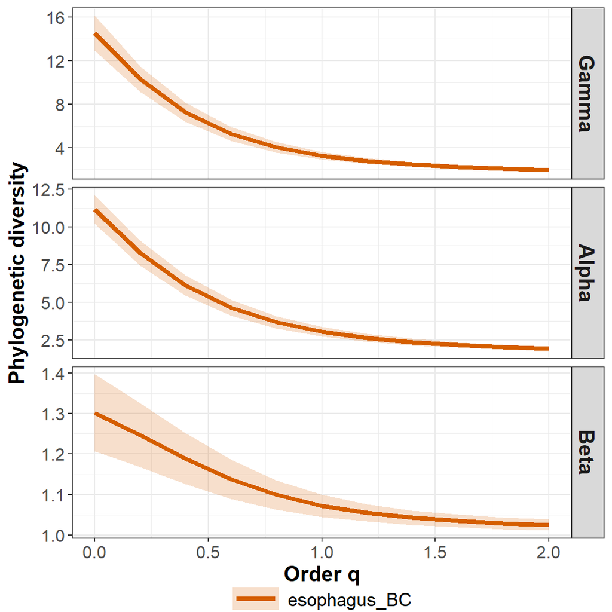

```r
ObsAsyPD_out = ObsAsyPD(data = esophagus[1], q = seq(0, 2, 0.2), nboot = 10,
                        PDtree = esophagus_tree)
ggObsAsyPD(ObsAsyPD_out, type = "B")
```

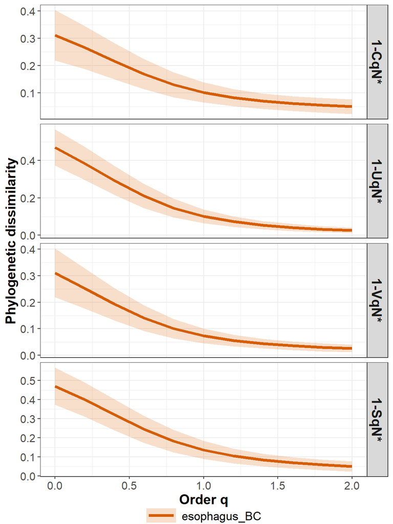

```r
ggObsAsyPD(ObsAsyPD_out, type = "D")
```

## ANALYSIS FOR HIERARCHICAL STRUCTURE DATA

### DATA INPUT FORMAT

#### Individual-based OTU count data

Input data for each data set with several assemblages/sites include samples species abundances in an empirical sample of n individuals (“reference sample”). When there are N assemblages in a data set, input data consist of a list with an S by N abundance matrix.

A data set (a small example dataset from Chinese wetlands community) is included in `iNEXT.seq` package for illustration. The data consist a data.frames of five assemblages/habitats (“NE”, “NW”, “NC”, “YML” and “SC”).

Run the following code to `wetland` OTU count data: (Here we only show the first ten rows for the matrix)

```r
data("wetland")
wetland
```

```
#>           NE NW   NC YML  SC
#> OTU_32   132 10   17   0  32
#> OTU_50    12  4    9   1  37
#> OTU_305   15  0    1   0  18
#> OTU_408   14  4   24  10  23
#> OTU_6426  12  7   26   2 153
#> OTU_75     9  9    7   1  80
#> OTU_356   13  7   11   0  19
#> OTU_1    242 71 1584  11  27
#> OTU_41    22  3   13   2  34
#> OTU_59    23 51    4   0  32
```

#### Phylogenetic tree for phylogenetic diversity

To perform phylogenetic diversity analysis, the phylogenetic tree (in Newick format) spanned by species observed in the pooled data is required. For the data set `wetland`, the phylogenetic tree for all observed species (including species in “NE”, “NW”, “NC”, “YML” and “SC”) is stored in the file `wetland_tree`. A partial list of the tip labels and node labels (not required) are shown below.

```r
data("wetland_tree")
wetland_tree
```

```
#>
#> Phylogenetic tree with 404 tips and 403 internal nodes.
#>
#> Tip labels:
#>   OTU_3829, OTU_705, OTU_3570, OTU_18, OTU_2733, OTU_108, ...
#>
#> Rooted; includes branch lengths.
```

#### Structure matrix for hierarchical phylogenetic diversity

In addition to OTU count data and phylogenetic tree, a hierarchical structure matrix of data is required. The structure of matrix is m x N (number of hierarchical layers times number of assemblages). The hierarchical structure matrix of data set `wetland` are shown below.

```r
data("wetland_mat")
wetland_mat
```

```
#>      [,1]  [,2]  [,3]  [,4]  [,5]
#> [1,] "All" "All" "All" "All" "All"
#> [2,] "IW"  "IW"  "CW"  "CW"  "CW"
#> [3,] "NE"  "NW"  "NC"  "YML" "SC"
```

### MAIN FUNCTION: hierPD()

We first describe the main function `hierPD()` with default arguments:

```r
hierPD(data, mat, q = seq(0, 2, 0.2), weight = "size", nboot = 10, conf = 0.95,
       PDtree, type = "mle", decomposition = "relative")
```

The arguments of this function are briefly described below, and will be explained in more details by illustrative examples in later text. This main function computes observed and asymptotic diversity of order q between 0 and 2 (in increments of 0.2) for hierarchical phylogenetic diversity; these values with different order q can be used to depict a q-profile in the `gghierPD` function.

| Argument | Description |
| --- | --- |
| `data` | data should be input as a `matrix/data.frame` (species by assemblages). |
| `mat` | hierarchical structure of data should be input as a `matrix`. |
| `q` | a numerical vector specifying the diversity orders. Default is `seq(0, 2, 0.2)`. |
| `weight` | (required only when `type = “mle”` and decomposition = “relative” ) weight for relative decomposition empirical estimate. Select size-weighted (`“size”`), equal-weighted (`“equal”`) or a numerical vec… |
| `nboot` | a positive integer specifying the number of bootstrap replications when assessing sampling uncertainty and constructing confidence intervals. Bootstrap replications are generally time consuming. Enter… |
| `conf` | a positive number < 1 specifying the level of confidence interval. Default is `0.95`. |
| `PDtree` | a `phylo`, a phylogenetic tree in Newick format for all observed species in the pooled assemblage. |
| `type` | estimate type: empirical (`type = “mle”`) or asymptotic estimate (`type = “est”`). Default is `“mle”`. |
| `decomposition` | decomposition type: relative (`decomposition = “relative”`) or absolute decomposition (`decomposition = “absolute”`). Default is `“relative”`. |

This function returns an `"hierPD"` object which can be further used to make plots using the function `gghierPD()` to be described below.

#### Examples

Run the `hierPD()` function with `wetland` data to compute empirical estimate for relative decomposition of hierarchical phylogenetic diversity. (Here we only show the first fifteen rows for output data frame)

```r
data("wetland")
data("wetland_mat")
data("wetland_tree")

hierPD_out = hierPD(data = wetland, mat = wetland_mat, q = seq(0, 2, 0.2),
                    nboot = 10, PDtree = wetland_tree)
```

```
#>            Method Order.q Estimator Bootstrap S.E.    LCL    UCL Decomposition
#> 10     qPD_alpha1       0    82.280          0.550 81.202 83.358      relative
#> 11     qPD_alpha2       0    87.694          0.527 86.662 88.726      relative
#> 12      qPD_gamma       0    89.618          0.000 89.618 89.618      relative
#> 13     qPD_Beta 1       0     1.066          0.002  1.061  1.070      relative
#> 14     qPD_Beta 2       0     1.022          0.006  1.010  1.034      relative
#> 15 qPD_Beta_max 1       0     2.362          0.010  2.343  2.382      relative
#> 16 qPD_Beta_max 2       0     2.000          0.000  2.000  2.000      relative
#> 17    1-CqN*(1|2)       0     0.048          0.002  0.045  0.052      relative
#> 18    1-CqN*(2|3)       0     0.022          0.006  0.010  0.034      relative
#> 19    1-UqN*(1|2)       0     0.107          0.003  0.100  0.114      relative
#> 20    1-UqN*(2|3)       0     0.043          0.012  0.020  0.066      relative
#> 21    1-VqN*(1|2)       0     0.048          0.002  0.045  0.052      relative
#> 22    1-VqN*(2|3)       0     0.022          0.006  0.010  0.034      relative
#> 23    1-SqN*(1|2)       0     0.107          0.003  0.100  0.114      relative
#> 24    1-SqN*(2|3)       0     0.043          0.012  0.020  0.066      relative
```

The output contains a data frames, it includes the estimate (`Estimator`) of hierarchical diversity (`qPD_gamma`, `qPD_alpha`, `qPD_Beta` and `qPD_Beta_max`) and four types dissimilarity measure (`1-CqN`, `1-UqN`, `1-VqN`, `1-SqN`), the diversity order (`Order.q`), the standard error from bootstrap replications (`Bootstrap S.E.`), the 95% lower and upper confidence limits of diversity (`LCL`, `UCL`), and beta diversity decomposition type (`Decomposition`). These diversity estimates with confidence intervals are used for plotting the diversity curve.

### GRAPHIC DISPLAYS: FUNCTION gghierPD()

The function `gghierPD()`, which extends `ggplot2` to the `"hierPD"` object with default arguments, is described as follows:

```r
gghierPD(output, type = "A")
```

| Argument | Description |
| --- | --- |
| `output` | the output of `hierPD`. |
| `type` | selection of plot type: (`type = “A”`) for alpha and gamma diversity; (`type = “B”`) for beta diversity; ( type = “D” ) for dissimilarity measure based on multiplicative decomposition. |

The `gghierPD()` function is a wrapper around the `ggplot2` package to create a q-profile using a single line of code. The resulting object is of class `"ggplot"`, so it can be manipulated using the `ggplot2` tools. Users can visualize the output of beta diversity or four dissimilarities by setting the parameter `type`:

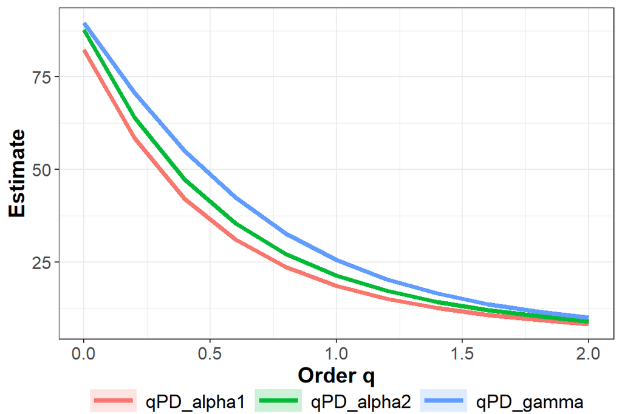

```r
hierPD_out = hierPD(data = wetland, mat = wetland_mat, q = seq(0, 2, 0.2),
                    nboot = 10, PDtree = wetland_tree)
gghierPD(hierPD_out, type = "A")
```

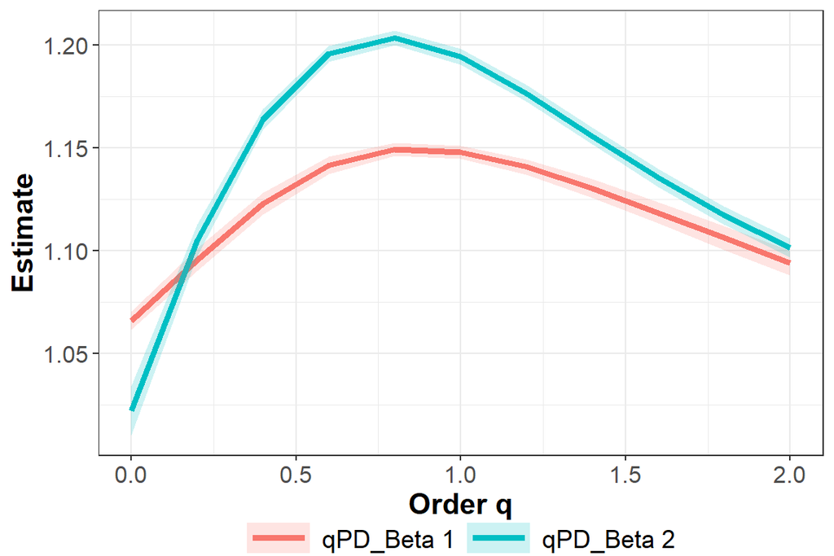

```r
gghierPD(hierPD_out, type = "B")
```

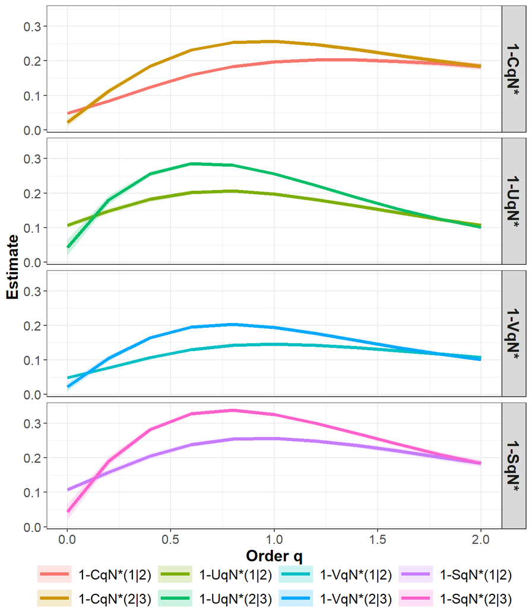

```r
gghierPD(hierPD_out, type = "D")
```

## References

- Chiu, C.-H., Jost, L. and Chao*, A. (2014). Phylogenetic beta diversity, similarity, and differentiation measures based on Hill numbers. *Ecological Monographs*, 84, 21-44.
- Routledge, R. (1979). Diversity indices: which ones are admissible? *Journal of Theoretical Biology*, 76(4), 503-515.